# Gian Mella Check Up Memo

Final Project (302)

Author

Gian Mella

Published

November 14, 2022

## Data Source

My primary data source is from Stathead: https://stathead.com/tiny/hXqZ6.

This dataset lists every NBA player who played over 10 minutes per game in last year’s playoffs (2021-22 NBA season), sorted by descending win shares. This table shows a wide variety of data for each player, such as per game stats, shooting percentages, and some advanced statistics as well. There are 152 players in the dataset.

## Demonstration of Progress

```r
# loading packages

library(tidyverse)
library(janitor)
library(skimr)

bball_data <- read_csv("data/unprocessed/Bball_data.txt") %>%
  clean_names()

skim_without_charts(bball_data)
```

Data summary

| Name | bball_data |
| --- | --- |
| Number of rows | 152 |
| Number of columns | 41 |
| _______________________ |  |
| Column type frequency: |  |
| character | 5 |
| numeric | 36 |
| ________________________ |  |
| Group variables | None |

**Variable type: character**

| skim_variable | n_missing | complete_rate | min | max | empty | n_unique | whitespace |
| --- | --- | --- | --- | --- | --- | --- | --- |
| player | 0 | 1 | 8 | 21 | 0 | 152 | 0 |
| season | 0 | 1 | 7 | 7 | 0 | 1 | 0 |
| team | 0 | 1 | 3 | 3 | 0 | 16 | 0 |
| pos | 0 | 1 | 1 | 3 | 0 | 7 | 0 |
| x9999 | 0 | 1 | 8 | 9 | 0 | 152 | 0 |

**Variable type: numeric**

| skim_variable | n_missing | complete_rate | mean | sd | p0 | p25 | p50 | p75 | p100 |
| --- | --- | --- | --- | --- | --- | --- | --- | --- | --- |
| rk | 0 | 1.00 | 76.50 | 44.02 | 1.00 | 38.75 | 76.50 | 114.25 | 152.00 |
| ws_3 | 0 | 1.00 | 0.57 | 0.71 | -0.50 | 0.10 | 0.30 | 0.80 | 3.80 |
| mp_4 | 0 | 1.00 | 25.89 | 9.72 | 10.00 | 16.88 | 26.70 | 34.90 | 44.00 |
| o_rtg | 0 | 1.00 | 112.09 | 15.62 | 58.00 | 103.00 | 113.00 | 121.00 | 163.00 |
| d_rtg | 0 | 1.00 | 112.97 | 6.27 | 99.00 | 108.00 | 113.00 | 117.00 | 128.00 |
| bpm | 0 | 1.00 | 0.72 | 3.80 | -9.60 | -1.33 | 0.80 | 2.82 | 11.80 |
| per | 0 | 1.00 | 13.98 | 5.86 | 0.50 | 10.07 | 13.35 | 16.83 | 33.10 |
| vorp | 0 | 1.00 | 0.25 | 0.39 | -0.30 | 0.00 | 0.15 | 0.30 | 2.20 |
| ws_10 | 0 | 1.00 | 0.57 | 0.71 | -0.50 | 0.10 | 0.30 | 0.80 | 3.80 |
| age | 0 | 1.00 | 27.05 | 4.12 | 20.00 | 24.00 | 27.00 | 30.00 | 36.00 |
| g | 0 | 1.00 | 9.89 | 5.97 | 1.00 | 5.00 | 6.00 | 13.00 | 24.00 |
| gs | 0 | 1.00 | 5.70 | 6.39 | 0.00 | 0.00 | 4.00 | 8.25 | 24.00 |
| mp_16 | 0 | 1.00 | 25.89 | 9.72 | 10.00 | 16.88 | 26.70 | 34.90 | 44.00 |
| fg | 0 | 1.00 | 4.09 | 2.57 | 0.20 | 2.00 | 3.45 | 5.50 | 12.20 |
| fga | 0 | 1.00 | 9.02 | 5.58 | 1.00 | 4.20 | 7.75 | 13.05 | 23.80 |
| x2p | 0 | 1.00 | 2.83 | 2.20 | 0.00 | 1.20 | 2.20 | 4.00 | 11.20 |
| x2pa | 0 | 1.00 | 5.39 | 4.19 | 0.20 | 2.18 | 4.30 | 7.53 | 20.30 |
| x3p | 0 | 1.00 | 1.26 | 0.95 | 0.00 | 0.50 | 1.10 | 1.83 | 4.10 |
| x3pa | 0 | 1.00 | 3.63 | 2.46 | 0.00 | 1.70 | 3.60 | 5.30 | 10.40 |
| ft | 0 | 1.00 | 1.96 | 1.91 | 0.00 | 0.60 | 1.40 | 2.73 | 8.50 |
| fta | 0 | 1.00 | 2.49 | 2.35 | 0.00 | 0.80 | 1.75 | 3.28 | 11.20 |
| orb | 0 | 1.00 | 1.01 | 0.89 | 0.00 | 0.38 | 0.80 | 1.40 | 5.50 |
| drb | 0 | 1.00 | 3.46 | 2.12 | 0.00 | 2.00 | 3.05 | 4.23 | 12.00 |
| trb | 0 | 1.00 | 4.47 | 2.74 | 0.00 | 2.68 | 3.85 | 5.70 | 14.30 |
| ast | 0 | 1.00 | 2.46 | 2.08 | 0.00 | 0.80 | 1.80 | 3.42 | 9.80 |
| stl | 0 | 1.00 | 0.77 | 0.47 | 0.00 | 0.40 | 0.80 | 1.02 | 2.10 |
| blk | 0 | 1.00 | 0.50 | 0.48 | 0.00 | 0.20 | 0.30 | 0.80 | 2.50 |
| tov | 0 | 1.00 | 1.44 | 1.16 | 0.00 | 0.60 | 1.10 | 1.92 | 6.20 |
| pf | 0 | 1.00 | 2.34 | 0.90 | 0.40 | 1.67 | 2.40 | 3.00 | 4.70 |
| pts | 0 | 1.00 | 11.38 | 7.29 | 1.00 | 5.47 | 9.45 | 15.40 | 31.70 |
| fg_percent | 0 | 1.00 | 0.46 | 0.11 | 0.18 | 0.40 | 0.45 | 0.50 | 1.00 |
| x2p_percent | 0 | 1.00 | 0.53 | 0.14 | 0.00 | 0.45 | 0.52 | 0.62 | 1.00 |
| x3p_percent | 10 | 0.93 | 0.33 | 0.13 | 0.00 | 0.28 | 0.35 | 0.40 | 0.67 |
| ft_percent | 7 | 0.95 | 0.77 | 0.17 | 0.00 | 0.70 | 0.80 | 0.87 | 1.00 |
| ts_percent | 0 | 1.00 | 0.57 | 0.10 | 0.20 | 0.52 | 0.57 | 0.62 | 1.00 |
| e_fg_percent | 0 | 1.00 | 0.53 | 0.11 | 0.18 | 0.47 | 0.53 | 0.59 | 1.00 |

I was able to successfully load in the my dataset and perfomed a quick skim of the data. To my relief, missingness was very minimal and easy to explain. But I knew I had to fix a few things with my data before I could proceed into making visualizations.

First, I got rid of of columns in the dataset that I felt were unnecessary, such as the age of the player, what season it is (since it’s the same for everyone), and some duplicate columns for minutes played and win shares.

```r
bball_data <-
  bball_data %>%
  select(-c(rk, ws_10, season, mp_16, x9999, age))
```

I also needed to change a lot of my column names. There are many columns that wouldn’t make sense when the average person is looking at my data, such as variables “g”, “x3pa”, or “x2p_percent”. I renamed those columns along with some others for increased clarity.

```r
bball_data <- rename(bball_data, `win_shares` = `ws_3`, `mins` = `mp_4`, `games_played` = `g`, `games_started` = `gs`, `2p` = `x2p`, `2pa` = `x2pa`, `3p` = `x3p`, `3pa` = `x3pa`, `fouls` = `pf`, `2p_percent` = `x2p_percent`, `3p_percent` = `x3p_percent`, `efg_percent` = `e_fg_percent`, `position` = `pos`)
```

In addition, for all the shooting percentage variables, I noticed that they were in terms of decimals and not shooting percentages. For example a 51.3% mark from 3pt range is listed as “.513”. I’d rather have it as a percentage, so I converted all of those shooting decimals to percentages by multiplying by 100.

```r
bball_data1 <- bball_data %>%
  mutate(
  `fg_percent` = `fg_percent` * 100,
  `2p_percent` = `2p_percent` * 100,
  `3p_percent` = `3p_percent` * 100,
  `ft_percent` = `ft_percent` * 100,
  `ts_percent` = `ts_percent` * 100,
  `efg_percent` = `efg_percent` * 100
  )
```

Lastly, I’m going create a little visualization that gives me a glimpse into Jimmy Butler’s overall playoff performance last year versus everyone else. The following chart shows Butler’s points per game versus the league average.

```r
(jimmy_comparison <- bball_data1 %>%
  mutate(player = ifelse(player == "Jimmy Butler", "Jimmy Butler", "All Other Players")) %>%
  group_by(player) %>%
  summarize(`Points Per Game (2021-22 Playoffs)` = mean(`pts`))
)
```

```
# A tibble: 2 × 2
  player            `Points Per Game (2021-22 Playoffs)`
  <chr>                                            <dbl>
1 All Other Players                                 11.3
2 Jimmy Butler                                      27.4
```

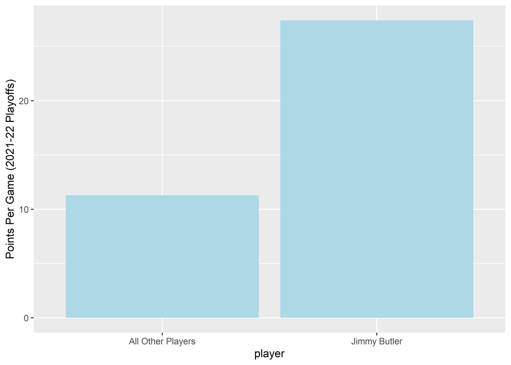

```r
jimmy_comparison %>%
  ggplot(aes(player, `Points Per Game (2021-22 Playoffs)`)) +
  geom_col(fill = "light blue")
```

## Assessment of Progress

I am pretty satisfied with the progress I have made so far. Loading the data was pretty simple, and I didn’t run into any major problems with my data that stalled my work. Every fix that I wanted to make with my dataset I was able to do. In the time that I’ve spent exploring and working with the data, I’ve already developed some ideas for visualizations I can possibly make. I think I am on track with this project and actually hope to start working on it earlier and potentially submit it by the early deadline.